# Recalling Words

```r
SFR <- subset(Friendly, condition == "SFR")
Before <- subset(Friendly, condition == "Before")
Meshed <- subset(Friendly, condition == "Meshed")
x <- c(Meshed$correct)
y <- c(Before$correct)
z <- c(SFR$correct)
```

```r
# Play the chunk above and this one to get the data into your Console
View(Friendly)
?Friendly
```

[figure not shown]

#### Background

Many teachers and other educators are interested in understanding how to best deliver new content to students. In general, they have two choices of how to do this.

1. The Meshed Approach
   - Deliver new content while simultaneously reviewing previously understood content.
2. The Before Approach
   - Deliver new content after fully reviewing previously understood content.

A study was performed to determine whether the *Meshed* or *Before* approaches to delivering content had any positive benefits on memory recall.

##### The Experiment (click to view)

##### The Data (click to view)

The purpose of this study was to figure out whether the Meshed or Before methods had any benefit on memory recall (the correctness) compared to the SFR (control). To accurately come to a conclusion whether or not any benefit was found, we will compare the difference in medians for both these methods up against the SFR (control).

Our null hypothesis and alternative hypothesis will be represented as:

$$H_0: \mu_\text{Difference in Medians} = 0$$

$$H_a: \mu_\text{Difference in Medians} \neq 0$$
Our significance level for this experiment will be set at:

$$\alpha = 0.05$$

### Analysis

The boxplot below shows the spread of the two different types of teaching, marked Before and Meshed, and lastly the control, marked SFR. From the graph we can see that the Before and Meshed method are very similar in spread while the SFR is much more broad.

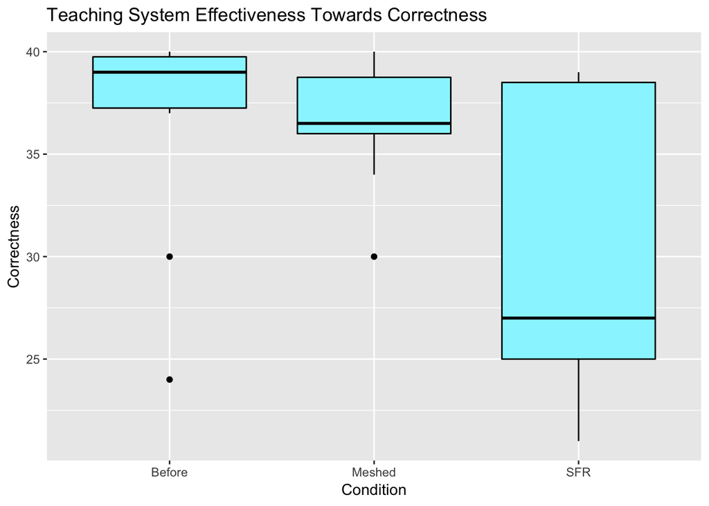

```r
ggplot(Friendly, aes(x=factor(condition), y=correct, )) +
  geom_boxplot(fill="cadetblue1",color="black")+
  labs(title = "Teaching System Effectiveness Towards Correctness", x = "Condition", y = "Correctness")
```

Here is a summary table for the two different teaching methods, in addition to the control. We can see that the Meshed method has a smaller spread than both the Before method and the control, it has a min of 30 and max of 40. On the other hand, we see that the Before method has a smaller Q1 to Q3 spread, with Q1 being 37.25 and Q3 being 39.75. We will have to conduct a Wilcoxon Signed-Rank Test (Paired) to see that data more in depth.

```r
outputTable <- rbind(`SFR (Control)`=favstats(SFR$correct), `Meshed`=favstats(Meshed$correct), `Before`=favstats(Before$correct))
pander(outputTable[c("min","Q1","median","mean","Q3","max","n")], caption="Teaching System Correctness Summary")
```

Teaching System Correctness Summary

|  | min | Q1 | median | mean | Q3 | max | n |
| --- | --- | --- | --- | --- | --- | --- | --- |
| **SFR (Control)** | 21 | 25 | 27 | 30.3 | 38.5 | 39 | 10 |
| **Meshed** | 30 | 36 | 36.5 | 36.6 | 38.75 | 40 | 10 |
| **Before** | 24 | 37.25 | 39 | 36.6 | 39.75 | 40 | 10 |

Wilcoxon Signed-Ranked Test (Paired) SFR and Meshed

```r
wilcox.test(z, x, mu = 0, alternative = "two.sided", paired = TRUE, conf.level = 0.95)
```

```
##
##  Wilcoxon signed rank test with continuity correction
##
## data:  z and x
## V = 8.5, p-value = 0.05884
## alternative hypothesis: true location shift is not equal to 0
```

Wilcoxon Signed-Ranked Test (Paired) SFR and Before

```r
wilcox.test(z, y, mu = 0, alternative = "two.sided", paired = TRUE, conf.level = 0.95)
```

```
##
##  Wilcoxon signed rank test with continuity correction
##
## data:  z and y
## V = 7.5, p-value = 0.08556
## alternative hypothesis: true location shift is not equal to 0
```

## Show Q-Q Plots

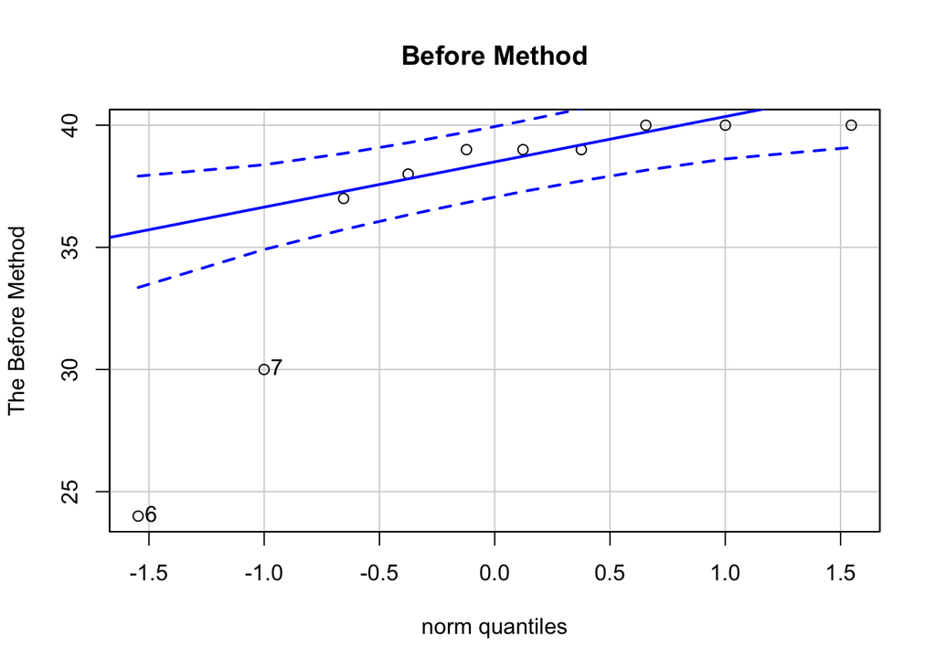

```
## [1] 6 7
```

```r
par(mfrow=c(1,1))

qqPlot(Before$correct, ylab = "The Before Method", main = "Before Method")
```

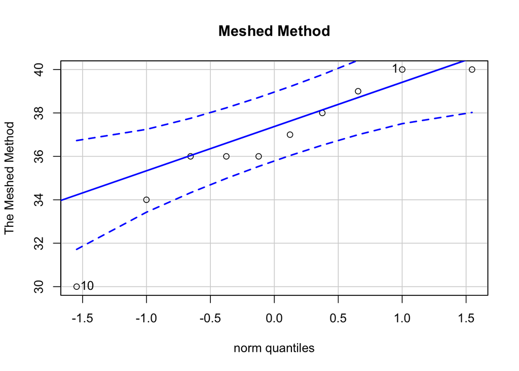

```
## [1] 10  1
```

```r
qqPlot(Meshed$correct, ylab = "The Meshed Method", main = "Meshed Method")
```

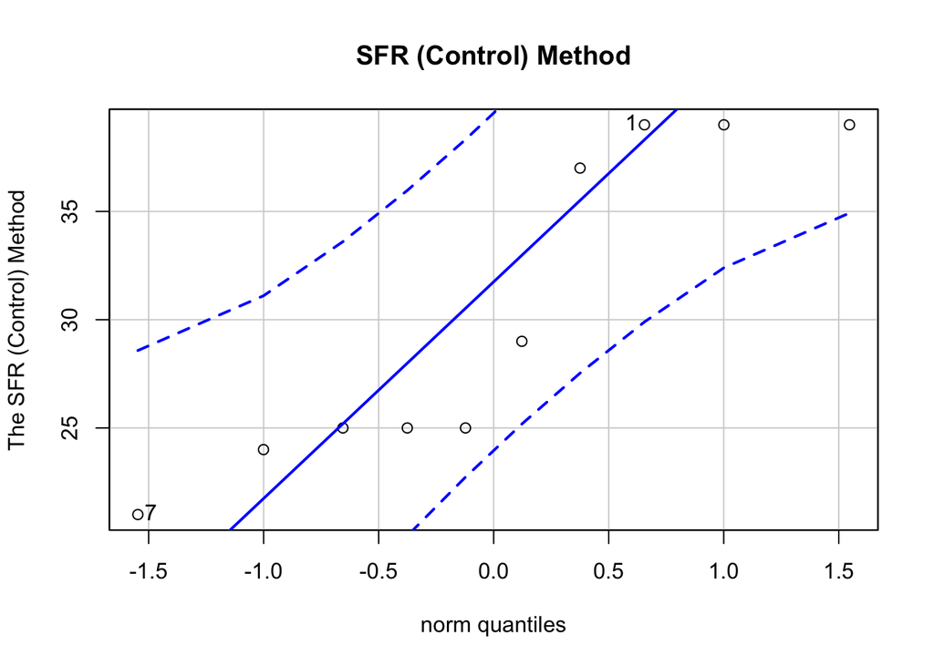

```
## [1] 7 1
```

```r
qqPlot(SFR$correct, ylab = "The SFR (Control) Method", main = "SFR (Control) Method")
```

The Q-Q plots above show us that the data does not have a normal spread, this is due to a small sample size that was taken. As shown in the summary table given before, there was only a sample size of 10 per each method of teaching.

### Interpretation

SFR and Meshed methods P-Value came out to ($p = 0.05884$). SFR and the Before methods P-Value came out to be ($p =0.08556$). Both of these methods P-values are greater than $\alpha = 0.05$ According to this data we have insufficient evidence to reject the null hypothesis. This means that we do not have enough evidence to support the idea of these different methods having a positive effect.